# Project: Investigate a Dataset (No-Show Appointments)

- Introduction
- Data Wrangling
- Exploratory Data Analysis
- Conclusions

## Introduction

No-Shows of appointments are a bitter reality in any medical practice. Not only it impacts the daily work flow of an operations but it can also cause financial issues in any type of organization. One cannot prevent patients from `No-Showing` for their appointments but the occurrences of `No-Shows` can be predicted or even reduced if you have the right data in hand.  
In this project, I will work on a dataset that collects information from 100k medical appointments in Brazil. It is focused on the question of whether or not patients show up for their appointment. I will base my analysis on the dataset and provide the insight on why and when an indivudual `No-Shows` or `Shows up` for an appointment.

# Posing Quetions:

1. Does age have any relations with no-showing for an appointment?
   - Do seniors tend to no-show more?
2. Do the patients who are NOT enrolled in Brasilian welfare program tend to no-show more than who are enrolled and vice versa?
3. What proportion of patients No-Shows who receives reminder calls vs who do not receive one?
4. Does patients medical condition/s have anything to do with No-Showing for their appointments?
5. Does the gap between the Schedule Date vs Appointment Date cause No-Shows?
6. what are the proportion of patients No-Showing weekday vs weekends?

```python
# Use this cell to set up import statements for all of the packages that you
#   plan to use.
import pandas as pd
import numpy as np
import matplotlib.pyplot as plt
import seaborn as sns
sns.set(style = 'whitegrid')
% matplotlib inline

# Remember to include a 'magic word' so that your visualizations are plotted
#   inline with the notebook. See this page for more:
#   http://ipython.readthedocs.io/en/stable/interactive/magics.html
```

## Data Wrangling

> **Tip**: In this section of the report, you will load in the data, check for cleanliness, and then trim and clean your dataset for analysis. Make sure that you document your steps carefully and justify your cleaning decisions.

### General Properties

```python
# Load the data and print out a few lines.
df = pd.read_csv('NoShow_DataSet.csv')
df.head()
```

|  | PatientId | AppointmentID | Gender | ScheduledDay | AppointmentDay | Age | Neighbourhood | Scholarship | Hipertension | Diabetes | Alcoholism | Handcap | SMS_received | No-show |
| --- | --- | --- | --- | --- | --- | --- | --- | --- | --- | --- | --- | --- | --- | --- |
| 0 | 2.987250e+13 | 5642903 | F | 2016-04-29T18:38:08Z | 2016-04-29T00:00:00Z | 62 | JARDIM DA PENHA | 0 | 1 | 0 | 0 | 0 | 0 | No |
| 1 | 5.589980e+14 | 5642503 | M | 2016-04-29T16:08:27Z | 2016-04-29T00:00:00Z | 56 | JARDIM DA PENHA | 0 | 0 | 0 | 0 | 0 | 0 | No |
| 2 | 4.262960e+12 | 5642549 | F | 2016-04-29T16:19:04Z | 2016-04-29T00:00:00Z | 62 | MATA DA PRAIA | 0 | 0 | 0 | 0 | 0 | 0 | No |
| 3 | 8.679510e+11 | 5642828 | F | 2016-04-29T17:29:31Z | 2016-04-29T00:00:00Z | 8 | PONTAL DE CAMBURI | 0 | 0 | 0 | 0 | 0 | 0 | No |
| 4 | 8.841190e+12 | 5642494 | F | 2016-04-29T16:07:23Z | 2016-04-29T00:00:00Z | 56 | JARDIM DA PENHA | 0 | 1 | 1 | 0 | 0 | 0 | No |

```python
# Inspect Data Types of each columns in the data set
df.info()
```

```
<class 'pandas.core.frame.DataFrame'>
RangeIndex: 110527 entries, 0 to 110526
Data columns (total 14 columns):
PatientId         110527 non-null float64
AppointmentID     110527 non-null int64
Gender            110527 non-null object
ScheduledDay      110527 non-null object
AppointmentDay    110527 non-null object
Age               110527 non-null int64
Neighbourhood     110527 non-null object
Scholarship       110527 non-null int64
Hipertension      110527 non-null int64
Diabetes          110527 non-null int64
Alcoholism        110527 non-null int64
Handcap           110527 non-null int64
SMS_received      110527 non-null int64
No-show           110527 non-null object
dtypes: float64(1), int64(8), object(5)
memory usage: 11.8+ MB
```

```python
# check if there are any duplicate rows of data
sum(df.duplicated())
```

```
0
```

```python
# Find number of unique values in the data set
df.nunique()
```

```
PatientId          61744
AppointmentID     110527
Gender                 2
ScheduledDay      103549
AppointmentDay        27
Age                  104
Neighbourhood         81
Scholarship            2
Hipertension           2
Diabetes               2
Alcoholism             2
Handcap                5
SMS_received           2
No-show                2
dtype: int64
```

### Data Cleaning

1. Work on **column labels**
2. **Check for null values** in the data set
3. Investigate **Age values**
4. **Convert the data type** (convert to DateTime format)

```python
# Correct the spelling errors in column names
df.rename(columns = {'Hipertension': 'Hypertension','Handcap': 'Handicap'}, inplace = True)

# Shorten the column names that are too long
df.rename(columns = {'AppointmentID': 'ApptId','ScheduledDay': 'SchedDate','AppointmentDay': 'ApptDate' }, inplace = True)

# Rename column No-Show to NoShow
df.rename(columns = {'No-show': 'status'}, inplace = True)
```

```python
# check for null values
df.isnull().sum().any() # below should print false if there are no null values
```

```
False
```

```python
# There are total 104 unique values in Age column above
# This tells me to investigate those values in Age column

print(sorted(df.Age.unique())) #print unique values
```

```
[-1, 0, 1, 2, 3, 4, 5, 6, 7, 8, 9, 10, 11, 12, 13, 14, 15, 16, 17, 18, 19, 20, 21, 22, 23, 24, 25, 26, 27, 28, 29, 30, 31, 32, 33, 34, 35, 36, 37, 38, 39, 40, 41, 42, 43, 44, 45, 46, 47, 48, 49, 50, 51, 52, 53, 54, 55, 56, 57, 58, 59, 60, 61, 62, 63, 64, 65, 66, 67, 68, 69, 70, 71, 72, 73, 74, 75, 7…
```

```python
# only include patients whose age is up to 100
# exclude -1 and 0 from the data set
df = df[(df.Age >= 0) & (df.Age <= 100)]
```

```python
# Confirm that unique Age values are between 1 t0 100
print(sorted(df.Age.unique())) #print unique values
```

```
[0, 1, 2, 3, 4, 5, 6, 7, 8, 9, 10, 11, 12, 13, 14, 15, 16, 17, 18, 19, 20, 21, 22, 23, 24, 25, 26, 27, 28, 29, 30, 31, 32, 33, 34, 35, 36, 37, 38, 39, 40, 41, 42, 43, 44, 45, 46, 47, 48, 49, 50, 51, 52, 53, 54, 55, 56, 57, 58, 59, 60, 61, 62, 63, 64, 65, 66, 67, 68, 69, 70, 71, 72, 73, 74, 75, 76, 7…
```

```python
# Now check how many records are in the data set
df.info()
```

```
<class 'pandas.core.frame.DataFrame'>
Int64Index: 110519 entries, 0 to 110526
Data columns (total 14 columns):
PatientId        110519 non-null float64
ApptId           110519 non-null int64
Gender           110519 non-null object
SchedDate        110519 non-null object
ApptDate         110519 non-null object
Age              110519 non-null int64
Neighbourhood    110519 non-null object
Scholarship      110519 non-null int64
Hypertension     110519 non-null int64
Diabetes         110519 non-null int64
Alcoholism       110519 non-null int64
Handicap         110519 non-null int64
SMS_received     110519 non-null int64
status           110519 non-null object
dtypes: float64(1), int64(8), object(5)
memory usage: 12.6+ MB
```

```python
# convert Sheduled Date and Appointment Date to appropriate data types
df['SchedDate'] = pd.to_datetime(df['SchedDate'])
df['ApptDate'] = pd.to_datetime(df['ApptDate'])
```

```python
# Converting SMS_Received columns value to more user friendly value

df['SMS_received'] = df.SMS_received.apply(lambda x: 'Yes' if x == 1 else 'No')
```

```python
# Converting Noshow columns value to more user friendly value

df['status'] = df.status.apply(lambda x: 'NoShow' if x=='Yes' else 'ShowUp')
```

```python
# Converting Gender columns value to more user friendly value

df['Gender'].replace ({'F':'Female', 'M':'Male'},inplace=True)
```

```python
# Create a dummy variable to store No Show value as 1 and 0
# split shows and no shows into 2 columns

df['status'] = df['status'].astype('category')
df = df.join(pd.get_dummies(df['status']))

#ns_dummy = pd.get_dummies(df.status, prefix='NoShow').iloc[:, 1:]
#df = pd.concat([df,ns_dummy],axis=1)
```

```python
# Create a dummy variable for gender
gender_dummy = pd.get_dummies(df.Gender, prefix='Gender').iloc[:, 1:]
df = pd.concat([df,gender_dummy],axis=1)
```

```python
# add a new column day of week in the data frame
# 0 being Monday ending with Sunday as 6
df['day'] = df['ApptDate'].dt.dayofweek
df.head()
```

|  | PatientId | ApptId | Gender | SchedDate | ApptDate | Age | Neighbourhood | Scholarship | Hypertension | Diabetes | Alcoholism | Handicap | SMS_received | status | NoShow | ShowUp | Gender_Male | day |
| --- | --- | --- | --- | --- | --- | --- | --- | --- | --- | --- | --- | --- | --- | --- | --- | --- | --- | --- |
| 0 | 2.987250e+13 | 5642903 | Female | 2016-04-29 18:38:08 | 2016-04-29 | 62 | JARDIM DA PENHA | 0 | 1 | 0 | 0 | 0 | No | ShowUp | 0 | 1 | 0 | 4 |
| 1 | 5.589980e+14 | 5642503 | Male | 2016-04-29 16:08:27 | 2016-04-29 | 56 | JARDIM DA PENHA | 0 | 0 | 0 | 0 | 0 | No | ShowUp | 0 | 1 | 1 | 4 |
| 2 | 4.262960e+12 | 5642549 | Female | 2016-04-29 16:19:04 | 2016-04-29 | 62 | MATA DA PRAIA | 0 | 0 | 0 | 0 | 0 | No | ShowUp | 0 | 1 | 0 | 4 |
| 3 | 8.679510e+11 | 5642828 | Female | 2016-04-29 17:29:31 | 2016-04-29 | 8 | PONTAL DE CAMBURI | 0 | 0 | 0 | 0 | 0 | No | ShowUp | 0 | 1 | 0 | 4 |
| 4 | 8.841190e+12 | 5642494 | Female | 2016-04-29 16:07:23 | 2016-04-29 | 56 | JARDIM DA PENHA | 0 | 1 | 1 | 0 | 0 | No | ShowUp | 0 | 1 | 0 | 4 |

```python
# get the stats on all the columns of data set
df.describe()
```

|  | PatientId | ApptId | Age | Scholarship | Hypertension | Diabetes | Alcoholism | Handicap | NoShow | ShowUp | Gender_Male | day |
| --- | --- | --- | --- | --- | --- | --- | --- | --- | --- | --- | --- | --- |
| count | 1.105190e+05 | 1.105190e+05 | 110519.000000 | 110519.000000 | 110519.000000 | 110519.000000 | 110519.000000 | 110519.000000 | 110519.000000 | 110519.000000 | 110519.000000 | 110519.000000 |
| mean | 1.474860e+14 | 5.675303e+06 | 37.084519 | 0.098273 | 0.197251 | 0.071870 | 0.030402 | 0.022213 | 0.201920 | 0.798080 | 0.350048 | 1.858251 |
| std | 2.560826e+14 | 7.129600e+04 | 23.103165 | 0.297684 | 0.397925 | 0.258274 | 0.171692 | 0.161441 | 0.401435 | 0.401435 | 0.476987 | 1.371657 |
| min | 3.920000e+04 | 5.030230e+06 | 0.000000 | 0.000000 | 0.000000 | 0.000000 | 0.000000 | 0.000000 | 0.000000 | 0.000000 | 0.000000 | 0.000000 |
| 25% | 4.172460e+12 | 5.640284e+06 | 18.000000 | 0.000000 | 0.000000 | 0.000000 | 0.000000 | 0.000000 | 0.000000 | 1.000000 | 0.000000 | 1.000000 |
| 50% | 3.172600e+13 | 5.680569e+06 | 37.000000 | 0.000000 | 0.000000 | 0.000000 | 0.000000 | 0.000000 | 0.000000 | 1.000000 | 0.000000 | 2.000000 |
| 75% | 9.438960e+13 | 5.725522e+06 | 55.000000 | 0.000000 | 0.000000 | 0.000000 | 0.000000 | 0.000000 | 0.000000 | 1.000000 | 1.000000 | 3.000000 |
| max | 9.999820e+14 | 5.790484e+06 | 100.000000 | 1.000000 | 1.000000 | 1.000000 | 1.000000 | 4.000000 | 1.000000 | 1.000000 | 1.000000 | 5.000000 |

```python
# Rename and save the edited data to another file
df.to_csv('NoShow_DataSet_Edited.csv', index = False)
```

## Exploratory Data Analysis

1. Out of the total appointments, how many people showed up vs did not show up for their appointment?
2. Does Gender has any correlation with No Showing for their appointments?
3. Does age have any relations with no-showing for an appointment?
   - Do seniors tend to no-show more?
4. Are people tend to No Show more on Weekdays vs Weekends? Which day of weeks have the highest No Shows?
5. Does patients medical condition/s have anything to do with No-Showing for their appointments?
6. Do the patients who are NOT enrolled in Brasilian welfare program tend to no-show more than who are enrolled and vice versa?
7. What proportion of patients No-Shows who receives reminder calls vs who do not receive one?

### Let us look at how data is distributed amongst various features.

```python
df.head()
```

|  | PatientId | ApptId | Gender | SchedDate | ApptDate | Age | Neighbourhood | Scholarship | Hypertension | Diabetes | Alcoholism | Handicap | SMS_received | status | NoShow | ShowUp | Gender_Male | day |
| --- | --- | --- | --- | --- | --- | --- | --- | --- | --- | --- | --- | --- | --- | --- | --- | --- | --- | --- |
| 0 | 2.987250e+13 | 5642903 | Female | 2016-04-29 18:38:08 | 2016-04-29 | 62 | JARDIM DA PENHA | 0 | 1 | 0 | 0 | 0 | No | ShowUp | 0 | 1 | 0 | 4 |
| 1 | 5.589980e+14 | 5642503 | Male | 2016-04-29 16:08:27 | 2016-04-29 | 56 | JARDIM DA PENHA | 0 | 0 | 0 | 0 | 0 | No | ShowUp | 0 | 1 | 1 | 4 |
| 2 | 4.262960e+12 | 5642549 | Female | 2016-04-29 16:19:04 | 2016-04-29 | 62 | MATA DA PRAIA | 0 | 0 | 0 | 0 | 0 | No | ShowUp | 0 | 1 | 0 | 4 |
| 3 | 8.679510e+11 | 5642828 | Female | 2016-04-29 17:29:31 | 2016-04-29 | 8 | PONTAL DE CAMBURI | 0 | 0 | 0 | 0 | 0 | No | ShowUp | 0 | 1 | 0 | 4 |
| 4 | 8.841190e+12 | 5642494 | Female | 2016-04-29 16:07:23 | 2016-04-29 | 56 | JARDIM DA PENHA | 0 | 1 | 1 | 0 | 0 | No | ShowUp | 0 | 1 | 0 | 4 |

Based on the histograms of columns in the dataset, which of the following feature variables appear skewed to the right?  
Form the histograms below, it seems that all the factors are skewed to the right except day of week. However, we will look into each factors to determine which factor impacts the no shows the most.

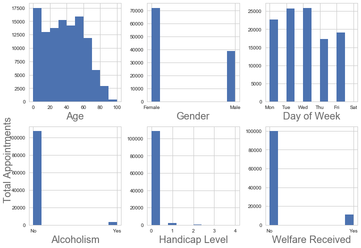

```python
fig, axes = plt.subplots(nrows=2,ncols = 3, figsize = (10,7))

#Age Subplot
age = df['Age'].hist(ax=axes[0,0]);
age.set_xlabel('Age', fontsize=20, alpha = 0.7);

#Gender Subplot
gender = df['Gender_Male'].astype(int).hist(ax=axes[0,1]);
gender.set_xlabel('Gender', fontsize=20, alpha = 0.7);
plt.sca(axes[0, 1])
plt.xticks(range(2), ['Female', 'Male'])

#Day of Week Subplot
day = df['day'].hist(ax=axes[0,2]);
day.set_xlabel('Day of Week', fontsize=20, alpha = 0.7);
plt.sca(axes[0, 2])
plt.xticks(range(6), ['Mon', 'Tue','Wed', 'Thu', 'Fri', 'Sat'])

#Alcohol Subplot
alc = df['Alcoholism'].astype(int).hist(ax=axes[1,0]);
alc.set_xlabel('Alcoholism', fontsize=20, alpha = 0.7);
alc.set_xlabel('Alcoholism', fontsize=20, alpha = 0.7);
plt.sca(axes[1, 0])
plt.xticks(range(2), ['No', 'Yes'])


#Handicap Subplot
han = df['Handicap'].hist(ax=axes[1,1]);
han.set_xlabel('Handicap Level', fontsize=20, alpha = 0.7)


sch = df['Scholarship'].astype(int).hist(ax=axes[1,2]);
sch.set_xlabel('Welfare Received', fontsize=20, alpha = 0.7)
plt.sca(axes[1, 2])
plt.xticks(range(2), ['No', 'Yes'])

fig.text(0.0002, 0.5, 'Total Appointments',fontsize=20, alpha = 0.7, rotation = 'vertical')

plt.tight_layout()
```

### Research Question 1 - Out of the total appointments, how many people showed up vs did not show up for their appointment?

```python
# count total number of No Show and Show ups
total = df.groupby(['status'])['ApptId'].count()
total
```

```
status
NoShow    22316
ShowUp    88203
Name: ApptId, dtype: int64
```

```python
# compute total number of appointments
Overall = total [1] + total [0]
Overall
```

```
110519
```

Out of 110519 appointments, 88203 showed up and 22316 were No Showed for their appointments.

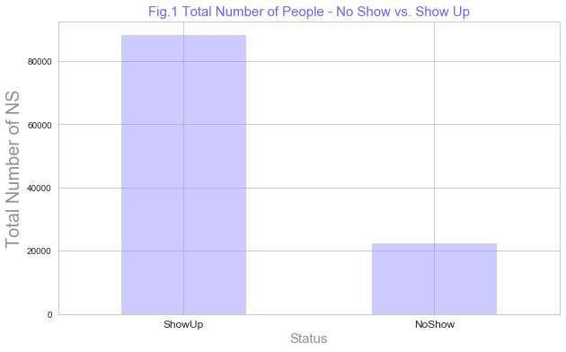

```python
# Display total Show ups vs No Shows
df.status.value_counts().plot(kind='bar', alpha = 0.5, facecolor = '#9999ff', figsize=(10,6))
plt.title("Fig.1 Total Number of People - No Show vs. Show Up", fontsize = 15, color = "b", alpha = 0.6)
plt.xlabel('Status', fontsize=15, alpha=0.5)
plt.ylabel("Total Number of NS", fontsize=20, alpha=0.5)
plt.xticks(rotation=0, fontsize=12)
plt.grid(True)
```

## Is gender associated with No-Show of appointments?

No, gender has no correlation with no showing for an appointment.

```python
#Count No Shows and Show ups by Gender
gender = pd.crosstab(df.Gender, df.status)
gender
```

| status Gender | NoShow | ShowUp |
| --- | --- | --- |
| Female | 14591 | 57241 |
| Male | 7725 | 30962 |

```python
#Find proportion of No Shows vs Shows Ups by Gender
gender_prop = gender.apply(lambda r: r/r.sum(), axis=1)
gender_prop
```

| status Gender | NoShow | ShowUp |
| --- | --- | --- |
| Female | 0.203127 | 0.796873 |
| Male | 0.199679 | 0.800321 |

```python
 # now stack and reset
stacked = gender_prop.stack().reset_index().rename(columns={0:'Proportions'})
pct = stacked['Proportions']*100
pct
```

```
0    20.312674
1    79.687326
2    19.967948
3    80.032052
Name: Proportions, dtype: float64
```

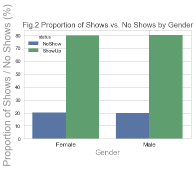

```python
# plot bar chart to display proportion of No Shows and Shows up by Gender
sns.barplot(x=stacked.Gender, y=pct, hue=stacked.status);
plt.title("Fig.2 Proportion of Shows vs. No Shows by Gender", fontsize = '15', alpha = 0.8);
plt.xlabel('Gender', fontsize=15, alpha=0.5)
plt.ylabel("Proportion of Shows / No Shows (%)", fontsize=20, alpha=0.5)
plt.xticks(fontsize=12)
#plt.yticks([0,10,20,30,40,50,60,70,80])
plt.grid(True)
```

### Does age have any relationship with no-showing for an appointment? Do seniors tend to no-show more?

From the Fig 3 below, it is evident that there is a negative correlation between Age and No Shows.  
It indicates that people who are younger than 40 are more likely to No Show frequenty in comparison to the people who are aged between 40-70. Before I began the data analysis process, my assumption was that seniors would more likely to No Show more than younger group of people. But the analysis below proves my assumption wrong.

```python
def crosstab(dataset, group_by):
    ct = pd.crosstab(index = dataset[group_by], columns = dataset.NoShow).reset_index()
    ct['ns_prob'] = (ct[1] / (ct[0] + ct[1]))*100
    return ct[[group_by, 'ns_prob']]
#print(crosstab(df,'Age'))
```

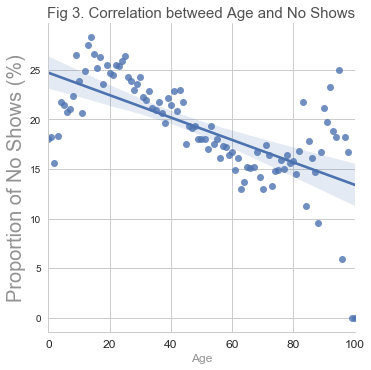

```python
age_plot = sns.lmplot( data = crosstab(df,'Age'),x = 'Age', y = 'ns_prob',  fit_reg = True)
plt.xlim(0, 100)
plt.title('Fig 3. Correlation betweed Age and No Shows', fontsize = '15', alpha = 0.8);
plt.xlabel('Age', fontsize=12, alpha=0.5)
plt.ylabel("Proportion of No Shows (%)", fontsize=20, alpha=0.5)
plt.xticks(fontsize=12)
plt.grid(True)
plt.show()
```

### Investigate further to identify which age group no shows frequently.

Let us divide the people into various age groups and find proportions of No Shows to identify which group of people tend to No Show more.  
I have divided the group of people into 4 different groups.

```python
# View the min, 25%, 50%, 75%, max Age values
df['Age'].describe()
```

```
count    110519.000000
mean         37.084519
std          23.103165
min           0.000000
25%          18.000000
50%          37.000000
75%          55.000000
max         100.000000
Name: Age, dtype: float64
```

```python
# create a new column in to identify the age group using the 5 values found above
bin_edges = [-1,19,38,56,100]
bin_names = ['1-19','20-38','39-56', 'Over57']
```

#### Find total number of appointments booked and No Shows by age group

The highest number of appointments i.e. 30411 were booked for people aged between 1-19. The least (25862) were booked by aged between 57-100.

```python
df['AgeGroup'] = pd.cut(df['Age'], bin_edges, labels=bin_names)

# Count total NoShows and Shows bynumber of appointments by Age group
df.groupby('AgeGroup').NoShow.count()

# count total Shows and NoShows
total = df.groupby('NoShow').count()['ApptId']
```

As shown below, the highest number of No Shows (6741) were by people in age group 1-19 whilst the least number of No Shows were by Over 57 age group.

```python
# Count number of No Shows by each age group
AgeGrp_count = df.groupby(['NoShow' ,'AgeGroup'])['NoShow'].count()
AgeGrp_count
```

```
NoShow  AgeGroup
0       1-19        23670
        20-38       20994
        39-56       21714
        Over57      21825
1       1-19         6741
        20-38        6340
        39-56        5198
        Over57       4037
Name: NoShow, dtype: int64
```

Compute proportion of No Shows from their total appointments by Age group.

```python
# get % of shows by age group
shows_prop = (AgeGrp_count [0] / total[0]) * 100

# get % of No Shows by age group
ns_prop = (AgeGrp_count [1] / total[1]) *100
```

```python
ind = np.arange(len(shows_prop))  # the x locations for the groups
width = 0.35       # the width of the bars
```

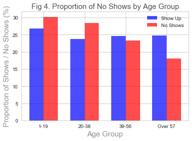

```python
# plot bars
shows_bars = plt.bar(ind, shows_prop, width, color='b', alpha=.7, label='Show Up')
noshow_bars = plt.bar(ind + width, ns_prop, width, color='r', alpha=.7, label='No Shows')

# title and labels
plt.ylabel('Proportion of Shows / No Shows (%)',fontsize=15, alpha=0.5)
plt.xlabel('Age Group', fontsize=15, alpha=0.5)
plt.title('Fig 4. Proportion of No Shows by Age Group', fontsize = '15', alpha = 0.8);
locations = ind + width / 2  # xtick locations
labels = ['1-19', '20-38', '39-56', 'Over 57']  # xtick labels
plt.xticks(locations, labels)

# legend
plt.legend();
```

#### Conclusion - Does Age have any relationship with No Shows?

After dividing the proportions of No-Shows by age group, it is possible to predict the probability of No-Shows by age group. In Figure 4 above, one can confirm that the people who are aged between 0-38 tend to no show more than their total scheduled appointments.

### Research Question 2 (Do people tend to No Show more on Weekdays vs Weekends? Which day of weeks have the highest No Shows?

Let us first find the correlation between Day of the Week and No Shows.

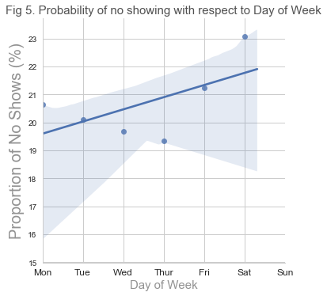

```python
# Use cross tab function (helper function) to plot no show proportion values
day_plot = sns.lmplot( data = crosstab(df,'day'),x = 'day', y = 'ns_prob',  fit_reg = True)
plt.xlim(0,6)
plt.title('Fig 5. Probability of no showing with respect to Day of Week', fontsize = '15', alpha = 0.8);
plt.xlabel('Day of Week', fontsize=15, alpha=0.5)
plt.ylabel("Proportion of No Shows (%)", fontsize=20, alpha=0.5)
plt.xticks([0,1,2,3,4,5,6],['Mon','Tue','Wed','Thur','Fri','Sat','Sun'],fontsize=12)
plt.grid(True)
plt.show()
```

There is a positive correlation between day of the week and No Shows. In other words, it indicates that people tend to No Show more towards the weekend.

### Let us look at the proportion of Shows vs No Shows to identify which day has highest proprtion of No Shows

```python
# count number of no shows by day of week
day_count = df.groupby(['NoShow', 'day']).count()['ApptId']

# total Shows and NoShows
day_total = df.groupby('NoShow').count()['ApptId']

# get proportions by dividing of show ups
shows_prop = (day_count [0] / day_total[0])*100

# get proportions by dividing of show ups
noshows_prop = (day_count [1] / day_total[1])*100

noshows_prop
```

```
day
0    21.011830
1    23.086575
2    22.822190
3    14.948916
4    18.090160
5     0.040330
Name: ApptId, dtype: float64
```

```python
ind = np.arange(len(shows_prop))  # the x locations for the groups
width = 0.35       # the width of the bars
```

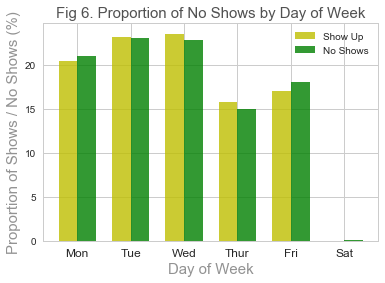

```python
# plot bars
shows_bars = plt.bar(ind, shows_prop, width, color='y', alpha=.8, label='Show Up')
noshow_bars = plt.bar(ind + width, noshows_prop, width, color='g', alpha=.8, label='No Shows')

# title and labels
plt.ylabel('Proportion of Shows / No Shows (%)', fontsize=15, alpha=0.5)
plt.xlabel('Day of Week', fontsize=15, alpha=0.5)
plt.title('Fig 6. Proportion of No Shows by Day of Week', fontsize = 15, alpha = 0.8)
locations = ind + width / 2  # xtick locations
Labels = ['Mon', 'Tue', 'Wed', 'Thur', 'Fri', 'Sat', 'Sun']  # xtick labels
plt.xticks(locations, Labels, fontsize = 12)

# legend
plt.legend();
```

### Does patients with medical condition/s have anything to do with No-Showing for their appointments?

```python
### Find correlation between other features in the data frame

# find the mean value of noshowsand show ups by different features such as
#Scholarship, Hypertension, Diabetes, Alcoholism, Handicap, SMS_received

# drop columns that are not required in this analysis
new = df.drop(df.columns[[0,1,5,15]],axis=1)

# find mean of  each features from "new" data frame
features = new.groupby(('status'),as_index=False).mean()

# reshape the data so that it can be plotted side by side in bar plot
features_df = pd.melt (features, id_vars=['status'], value_vars=['Handicap', 'Alcoholism',
                                                                 'Diabetes','Hypertension'])
#convert the proportions / mean values in percentage
features_df['value']= features_df['value'] * 100

#display final re-shaped data
features_df
```

|  | status | variable | value |
| --- | --- | --- | --- |
| 0 | NoShow | Handicap | 2.016490 |
| 1 | ShowUp | Handicap | 2.273165 |
| 2 | NoShow | Alcoholism | 3.033698 |
| 3 | ShowUp | Alcoholism | 3.041847 |
| 4 | NoShow | Diabetes | 6.407958 |
| 5 | ShowUp | Diabetes | 7.384103 |
| 6 | NoShow | Hypertension | 16.902671 |
| 7 | ShowUp | Hypertension | 20.439214 |

[figure not shown]

```python
# use above reshaped data to plot

sns.factorplot (x='variable', y = 'value', hue = 'status', data = features_df, size = 6, kind = 'bar')
plt.title("Fig 7. No Shows and Shows by various features", fontsize = 20, color = "g", alpha = 0.6)
plt.xlabel('Features', fontsize=20, alpha=0.5)
plt.ylabel('Proportion of Shows / No Shows (%)', fontsize=20, alpha=0.5)
plt.xticks(fontsize=12)
plt.yticks ([0.0,2.5,5.0,7.5,10.0,12.5,15.0,17.5,20.0],[0,3,6,9,12,15,18,21,24])
plt.show()
```

### Find correlation of No Shows against 2 factors - SMS Received and Welfare program.

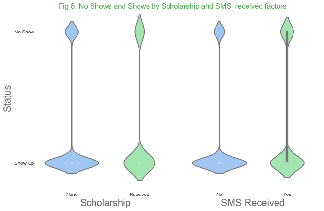

```python
# plot using pair grid to compare each factors side by side
g = sns.PairGrid(df,
                 x_vars=["Scholarship", "SMS_received"],
                 y_vars=["NoShow"],
                 aspect=.75, size=6);
g.map(sns.violinplot, palette="pastel") # map the violin plots to compare side by side

g.fig.get_axes()[0].set_xticklabels(["None", "Received"])
g.fig.get_axes()[0].set_xlabel('Scholarship', fontsize=20, alpha = 0.7)
g.fig.get_axes()[1].set_xlabel('SMS Received', fontsize=20, alpha = 0.7)
g.set(yticks=[0,1])
g.fig.get_axes()[0].set_yticklabels(["Show Up", "No Show"])
g.fig.get_axes()[0].set_ylabel('Status', fontsize=20, alpha = 0.7)

# plot title
plt.suptitle("Fig 8. No Shows and Shows by Scholarship and SMS_received factors",
          fontsize = 15, color = "g", alpha = 0.7)
```

From Figure 8 above, it is a clear indication that the proportion of No Show is higher despite receiving SMS prior to their appoitnments and also people who receives welfare are tend to No Show more than the ones who do not receive it.

### To conclude the statements above, let us find what proportion of patients No-Shows who receives SMS reminders vs who do not receive one.

```python
# total No Shows and Show ups by SMS_Received factor
SMS = pd.crosstab(df.SMS_received, df.status, margins=True)
SMS
```

| status SMS_received | NoShow | ShowUp | All |
| --- | --- | --- | --- |
| No | 12532 | 62506 | 75038 |
| Yes | 9784 | 25697 | 35481 |
| All | 22316 | 88203 | 110519 |

```python
# Proportions/Avergae of No Shows and Show ups by SMS_Received
SMS_prop = SMS.apply(lambda r: r/r.sum(), axis=1)
SMS_prop
```

| status SMS_received | NoShow | ShowUp | All |
| --- | --- | --- | --- |
| No | 0.083504 | 0.416496 | 0.5 |
| Yes | 0.137877 | 0.362123 | 0.5 |
| All | 0.100960 | 0.399040 | 0.5 |

### Now let us find proportions of No Show by - people who are enrolled in Brasilian welfare program or the the ones who are not enrolled.

```python
# total No Shows and Show ups by Scholarship_Received factor
welfare = pd.crosstab(df.Scholarship, df.status, margins=True)
welfare
```

| status Scholarship | NoShow | ShowUp | All |
| --- | --- | --- | --- |
| 0 | 19738 | 79920 | 99658 |
| 1 | 2578 | 8283 | 10861 |
| All | 22316 | 88203 | 110519 |

```python
# Average / Mean of No Shows and Show ups by Scholarship_Received factor
welfare_prop = welfare.apply(lambda r: r/r.sum(), axis=1)
welfare_prop
```

| status Scholarship | NoShow | ShowUp | All |
| --- | --- | --- | --- |
| 0 | 0.099029 | 0.400971 | 0.5 |
| 1 | 0.118682 | 0.381318 | 0.5 |
| All | 0.100960 | 0.399040 | 0.5 |

### Conclusion:

In this project, the data analysis process was conducted to predict the likelihood of a person no showing for their appointments. As mentioned previously, it is impossible to prevent a person from no showing for their appointments. However, with given data and imposing the right questions, the likelihood of no-shows can be predictable. Additionally, the true offenders (human or technology) can be identified to form a no-show policy i.e. charging a certain amount for no shows or improve existing systems.

After analyzing the factors above, we can conclude that with the given data it will be very difficult to make any moderate/strong prediction of the No Shows based on only one factor.

### Reference:

- Web sites - http://stackoverflow.com/, http://seaborn.pydata.org/tutorial.htm, http://www.google.com/
- books - Head First Python by Paul Barry
- blog posts - http://www.kaggle.com/